# Toy example in Appendix D

This notebook contains the code of the paper "Learning Physics between Digital Twins with Low-Fidelity Models and Physics-Informed Gaussian Processes". The models are fitted in rstan and the code is available in the folder "STAN/toy".

#### Load packages

```r
# uncomment to install
# install.packages("rstan")
# install.packages("ggplot2")
# install.packages("SAVE")
library(rstan)
library(ggplot2)
library(SAVE) # package with the data
rstan_options(auto_write = TRUE)
options(mc.cores = 3) # allocate 3 cores (for each model we run 3 chains in parallel)
```

#### Reality and modelling choice

**Note** that in the paper there is a mistake in the presentation. The coefficients of the true model $\mathcal{R}$ and model $M$ are swapped and the correct models are the following
$$\begin{align*}
y^\mathcal{R}(x) &= 3.5\cdot \exp(-u\cdot x)+b+\varepsilon \quad \text{ (the model we use to simulate data) }\\
\eta(x,u) &= 5\cdot \exp(-u\cdot x) \quad \text{ (the misspesified model we use to fit the data) }
\end{align*}$$

```r
R = function(u,x,b) 3.5*exp(-u*x)+b
sd_noise = 0.3
```

```r
data("synthfield") # data from the rpackage SAVE
X_loc = unique(synthfield$x)

# simulate data for different u val and add iid noise
u_val = seq(0.8,1.7,by=0.1)
dl=list()
set.seed(123)
offsets=runif(length(u_val),0.5,5) # sample offsets in [0.5,5]
# input locations with 3 relpicates
xobs = c(unique(synthfield$x),unique(synthfield$x),unique(synthfield$x)); N=length(xobs);
X_mat = matrix(NA, nrow = length(u_val), ncol = length(xobs))
set.seed(0)
# sample random input locations
dev=c(runif(length(u_val), 0.1,0.25))
for(i in 1:nrow(X_mat)){
  X_mat[i,] = xobs+dev[i]
}
# Predictions at 20 locations x_pred (both interpolation and extrapolation)
Ns = length(u_val) # total number of individuals
id = seq_along(u_val) # individual ids
N_pred=20
x_pred_vec=seq(0.1,5,length.out = N_pred);
x_pred = matrix(rep(x_pred_vec,Ns), nrow = Ns, ncol = N_pred, byrow = TRUE)
# add i.i.d. N(0,0.3^2) noise
for(i in seq_along(u_val)){
  set.seed(0)
  y=R(u_val[i], xobs, offsets[i])+rnorm(N,0,sd=sd_noise);
  dl[[i]] = list(x= X_mat[i,], y = y, N = N, x_pred=x_pred_vec, N_pred=N_pred)
}
y = matrix(NA, nrow = length(u_val), ncol = length(xobs))
for(i in 1:nrow(y)) y[i,] = dl[[i]]$y


# population data
data_population = list(x= X_mat, y = y, N = N, Ns=Ns, id=id, N_pred = N_pred, x_pred=x_pred)
```

### Model 1 (no-without delta in paper, Figure 3)

Predictions for the model that does not account for discrepancy

Stan code:

```r
writeLines(readLines('STAN/toy/toy_nodelta_pred.stan'))
```

```
data {
  int<lower=0> N;
  vector[N] x;
  vector[N] y;

  int<lower=0>N_pred;
  vector[N_pred] x_pred;
}
parameters {
  real<lower=0,upper=5> u;
  real<lower=0, upper=2> sigma;
}

model {
  // priors
  u ~ normal(1,2);
  // likelihood
  y ~ normal(5*exp(-u*x), sigma);
}
generated quantities {
  vector[N_pred] y_pred;
  for(n in 1:N_pred){
    y_pred[n] = normal_rng(5*exp(-u*x_pred[n]), sigma);
  }
}
```

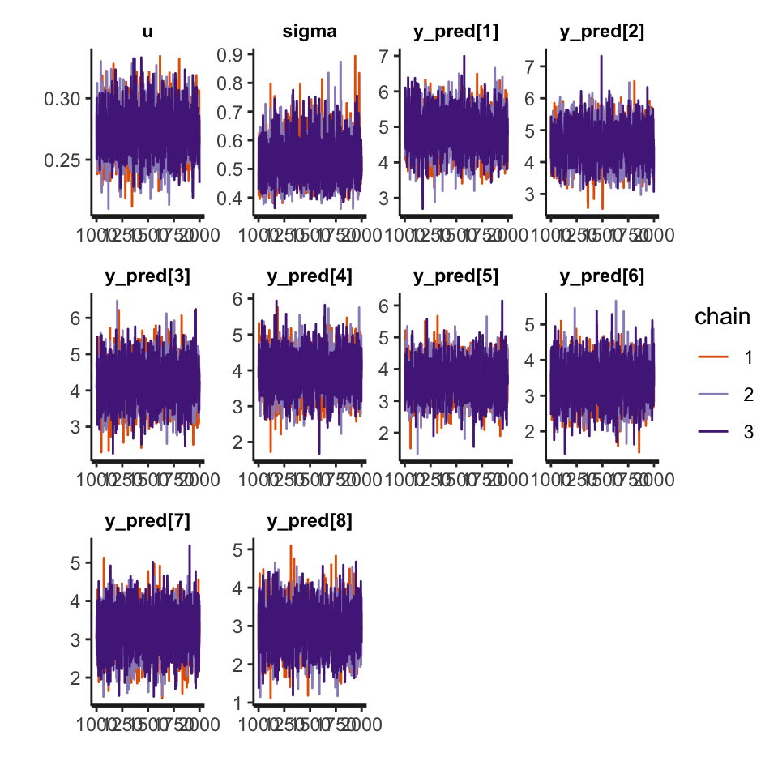

```r
#------------------------------------------------------------------------------------------
# Fit without accounting for discrepancy for each invidual separately (no-without delta))
lu_no=lpred_no=list()
for(i in seq_along(u_val)){
  fit_no_without_delta = stan(
    file='STAN/toy/toy_nodelta_pred.stan', # without delta
    data=dl[[i]],
    chains=3,
    iter=2*1000,
    seed=123
  )
  lu_no[[i]] = extract(fit_no_without_delta)$u
  smr_nnd=summary(fit_no_without_delta)$summary
  ind=grep("y_pred",rownames(smr_nnd))
  lpred_no[[i]]=smr_nnd[ind,c("mean", "2.5%", "97.5%")]
}
stan_trace(fit_no_without_delta)
```

```r
pred_nnd=data.frame(do.call(rbind, lpred_no))
pred_nnd$sharing = "no-without delta"
```

### Model 2 (no-with delta in paper, Figure 3)

```r
writeLines(readLines('STAN/toy/toy_delta_pred.stan'))
```

```
functions{ // squared exponential kernel
  matrix cov_exp(vector x,
                 real alpha,
                 real rho){
    int n = rows(x);
    matrix[n, n] K;
    // KP
    for (i in 1:(n)){
      K[i,i] = pow(alpha, 0.2e1);
      for (j in (i+1):n){
        K[i,j] = exp(-pow(x[i] - x[j], 0.2e1) * pow(rho, -0.2e1));
        K[i,j] = pow(alpha, 0.2e1) * K[i,j];
        K[j,i] = K[i,j];
      }
      K[n,n] = pow(alpha, 0.2e1);
    }
    return(K);
  }
}

data {
  int<lower=0> N;
  vector[N] x;
  vector[N] y;

  int<lower=0> N_pred;
  vector[N_pred] x_pred;
}
transformed data{
  int<lower=1> N_tot;
  N_tot=N+N_pred;
}
parameters {
  real<lower=0,upper=5> u; // physical parameter
  real<lower=0, upper=2> sigma; // noise parameter
  real<lower=0, upper=4> alpha; // marginal sd (delta)
  real<lower=0, upper=6> rho; // length scale (delta)
  // predictions
  vector[N_pred] y_pred;
}

model {
  vector[N_tot] x_tot;
  vector[N_tot] z;
  matrix[N_tot, N_tot] cov;
  matrix[N_tot, N_tot] L_cov;

  x_tot = append_row(x,x_pred);
  z = append_row(y,y_pred);
  cov = cov_exp(x_tot, alpha, rho)+diag_matrix(rep_vector(sigma^2, N_tot));
  L_cov = cholesky_decompose(cov);

  // priors
  u ~ normal(1,2);
  z ~ multi_normal_cholesky(5*exp(-u*x_tot), L_cov);
}
```

We fit this model to each individual data set separately

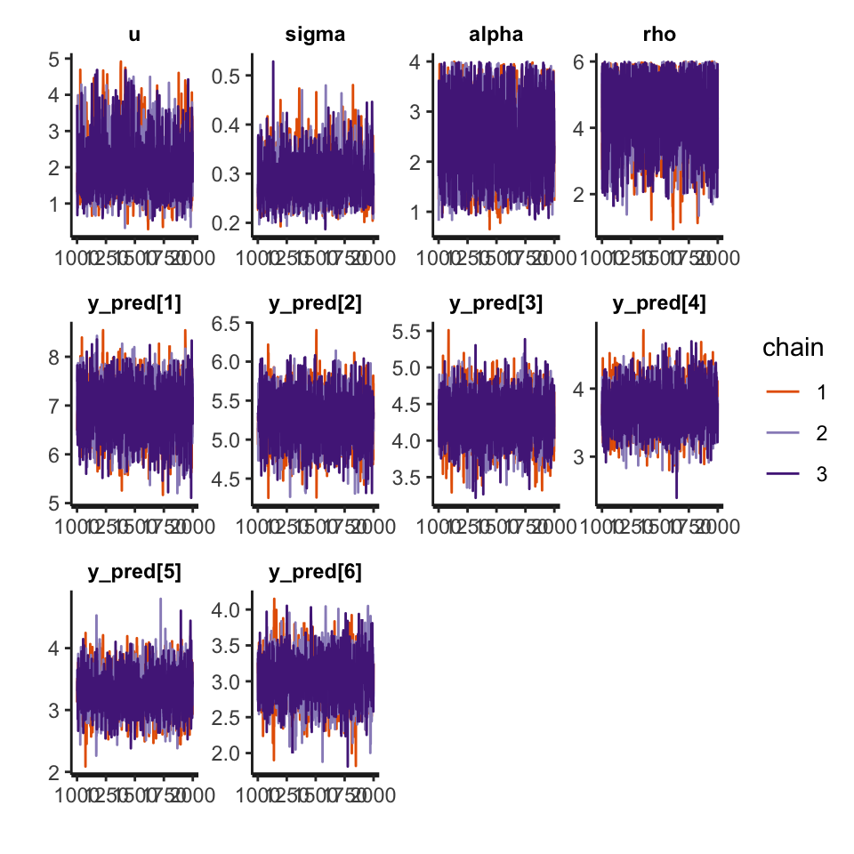

```r
#------------------------------------------------------------------------------------------
# Accounting for discrepancy for each invidual separately (no-with delta)
lu=lpred=list()
for(i in seq_along(u_val)){
  fit_no_with_delta = stan(
    file='STAN/toy/toy_delta_pred.stan', # with delta
    data=dl[[i]],
    chains=3,
    iter=2*1000,
    seed=123
  )
  lu[[i]] = extract(fit_no_with_delta)$u
  smr_nwd=summary(fit_no_with_delta)$summary
  ind=grep("y_pred",rownames(smr_nwd))
  lpred[[i]]=smr_nwd[ind,c("mean", "2.5%", "97.5%")]
}
stan_trace(fit_no_with_delta)
```

```r
pred_nwd=data.frame(do.call(rbind, lpred))
pred_nwd$sharing = "no-with delta"
```

### Model 3 (yes/common delta, Figure 3)

We allow individuals to share information about the physical parameters $u_m, m=1,2,\ldots,10$ through a global level parameter as described in Section 3.2. The model assumes same discrepancy parameters for all individuals.

Stan code:

```r
writeLines(readLines('STAN/toy/toy_common_delta_pred.stan'))
```

```
functions{ // squared exponential kernel
  matrix cov_exp(vector x,
                 real alpha,
                 real rho){
    int n = rows(x);
    matrix[n, n] K;
    // KP
    for (i in 1:(n)){
      K[i,i] = pow(alpha, 0.2e1);
      for (j in (i+1):n){
        K[i,j] = exp(-pow(x[i] - x[j], 0.2e1) * pow(rho, -0.2e1));
        K[i,j] = pow(alpha, 0.2e1) * K[i,j];
        K[j,i] = K[i,j];
      }
      K[n,n] = pow(alpha, 0.2e1);
    }
    return(K);
  }
}
data {
  int<lower=1> N; //number of observations per individual
  int<lower=1> Ns;
  int<lower=1,upper=Ns> id[Ns]; //number of individuals
  matrix[Ns, N] x; //different across individuals (e.g. time)
  matrix[Ns, N] y; //input data
  // predictions
  int<lower=0> N_pred;
  matrix[Ns, N_pred] x_pred;
}
transformed data{
  int<lower=1> N_tot;
  N_tot=N+N_pred;
}
parameters {
  real<lower=0, upper=3.0> u_tilde[Ns]; // non-centered parameterization

  real<lower=0, upper=4> alpha; // marginal sd (delta)
  real<lower=0, upper=6> rho;  // length scale (delta)

  real<lower=0> sigma; // noise sd
```

[output cut: 17 more lines]

```

  x_tot=append_col(x,x_pred);
  z= append_col(y,y_pred);
  for (s in 1:Ns) {
    cov[s] = cov_exp(to_vector(x_tot[s]), alpha, rho)+diag_matrix(rep_vector(sigma^2, N_tot));
    L_cov[s] = cholesky_decompose(cov[s]);
  }

  u_tilde ~ normal(0, 1);  // non-centered
  // likelihood
  for (i in 1:Ns){
        z[i] ~ multi_normal_cholesky(5*exp(-u[id[i]]*x_tot[i]), L_cov[id[i]]);

  }
}
```

```r
#------------------------------------------------------------------------------------------
# shared u common delta model
fit_yes_common_delta = stan(file='STAN/toy/toy_common_delta_pred.stan',
                            data=data_population,
                            chains=3,
                            iter=2*1000,
                            seed=123
)
names(fit_yes_common_delta)
```

```
  [1] "u_tilde[1]"    "u_tilde[2]"    "u_tilde[3]"    "u_tilde[4]"
  [5] "u_tilde[5]"    "u_tilde[6]"    "u_tilde[7]"    "u_tilde[8]"
  [9] "u_tilde[9]"    "u_tilde[10]"   "alpha"         "rho"
 [13] "sigma"         "mu"            "tau"           "y_pred[1,1]"
 [17] "y_pred[2,1]"   "y_pred[3,1]"   "y_pred[4,1]"   "y_pred[5,1]"
 [21] "y_pred[6,1]"   "y_pred[7,1]"   "y_pred[8,1]"   "y_pred[9,1]"
 [25] "y_pred[10,1]"  "y_pred[1,2]"   "y_pred[2,2]"   "y_pred[3,2]"
 [29] "y_pred[4,2]"   "y_pred[5,2]"   "y_pred[6,2]"   "y_pred[7,2]"
 [33] "y_pred[8,2]"   "y_pred[9,2]"   "y_pred[10,2]"  "y_pred[1,3]"
 [37] "y_pred[2,3]"   "y_pred[3,3]"   "y_pred[4,3]"   "y_pred[5,3]"
 [41] "y_pred[6,3]"   "y_pred[7,3]"   "y_pred[8,3]"   "y_pred[9,3]"
 [45] "y_pred[10,3]"  "y_pred[1,4]"   "y_pred[2,4]"   "y_pred[3,4]"
 [49] "y_pred[4,4]"   "y_pred[5,4]"   "y_pred[6,4]"   "y_pred[7,4]"
 [53] "y_pred[8,4]"   "y_pred[9,4]"   "y_pred[10,4]"  "y_pred[1,5]"
 [57] "y_pred[2,5]"   "y_pred[3,5]"   "y_pred[4,5]"   "y_pred[5,5]"
```

[output cut: 42 more lines]

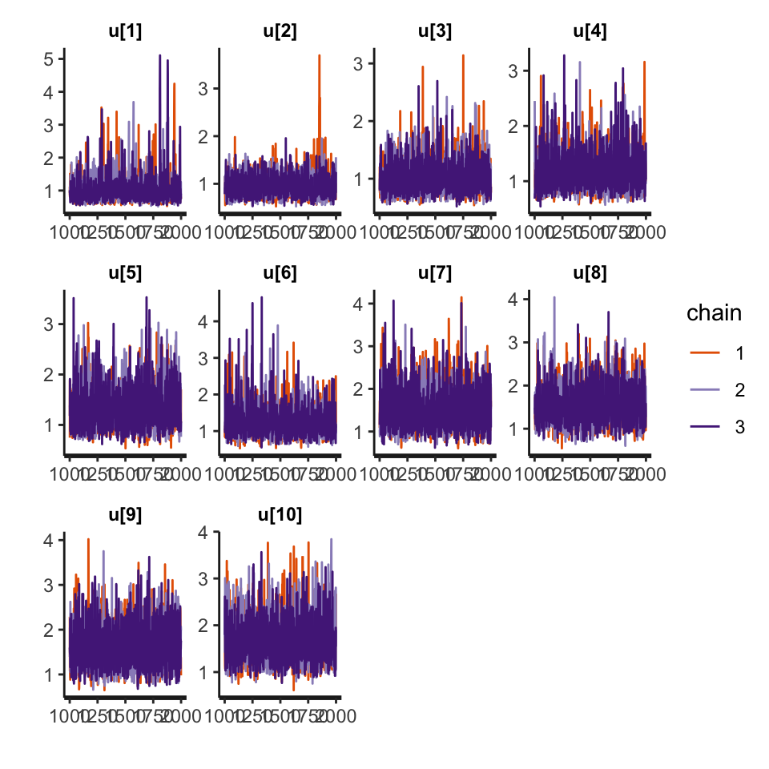

```r
stan_trace(fit_yes_common_delta, pars = "u")
```

```r
ex_ycd=extract(fit_yes_common_delta)
```

### Model 4 (yes/shared delta, Figure 3)

Stan code:

```r
writeLines(readLines('STAN/toy/toy_shared_delta_pred.stan'))
```

```
functions{
  matrix cov_exp(vector x,
                 real alpha,
                 real rho){
    int n = rows(x);
    matrix[n, n] K;
    // KP
    for (i in 1:(n)){
      K[i,i] = pow(alpha, 0.2e1);
      for (j in (i+1):n){
        K[i,j] = exp(-pow(x[i] - x[j], 0.2e1) * pow(rho, -0.2e1));
        K[i,j] = pow(alpha, 0.2e1) * K[i,j];
        K[j,i] = K[i,j];
      }
      K[n,n] = pow(alpha, 0.2e1);
    }
    return(K);
  }
}
data {
  int<lower=1> N; // number of observations per individual
  int<lower=1> Ns; // number of individuals
  int<lower=1,upper=Ns> id[Ns]; // individual id
  matrix[Ns, N] x; // individual input vector
  matrix[Ns, N] y; // matrix of all individual outputs
  // predictions
  int<lower=0> N_pred;
  matrix[Ns, N_pred] x_pred;
}
transformed data{
  int<lower=1> N_tot;
  N_tot=N+N_pred;
}
parameters {
  // non-centered parameterization parameters
  real<lower=0,upper=3.0> u_tilde[Ns];
  real rho_tilde[Ns];   // non-centered sd of rho (delta process)
  real alpha_tilde[Ns]; // non-centered sd of alpha (delta precess)
  real<lower=0> sigma;  // same noise across individuals

```

[output cut: 38 more lines]

```
  rho_m ~ inv_gamma(2, 0.5);
  alpha_m ~ normal(0,2);
  rho_s ~ normal(0, 0.5);
  alpha_s ~ normal(0, 0.5);

  // non-centered parameterization of individual parameters
  rho_tilde ~ normal(0, 1);
  alpha_tilde ~ normal(0, 1);
  u_tilde ~ normal(0, 1);

  // likelihood
  for (i in 1:Ns){
    z[i] ~ multi_normal_cholesky(5*exp(-u[id[i]]*x_tot[i]), L_cov[id[i]]);
  }
}
```

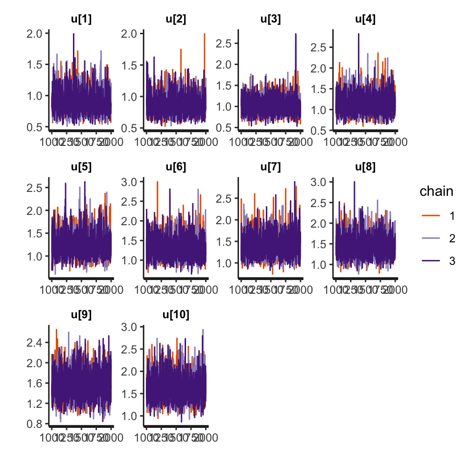

```r
#------------------------------------------------------------------------------------------
# shared u and delta model
fit_yes_shared_delta = stan(file='STAN/toy/toy_shared_delta_pred.stan',
                            data=data_population,
                            chains=3,
                            iter=2*1000,
                            seed=123
)
smr_ysd= summary(fit_yes_shared_delta)
stan_trace(fit_yes_shared_delta, pars = "u")
```

```r
ex_ycd=extract(fit_yes_shared_delta)
```

#### Plot predictions for all methods (Figure 2 in the Appendix)

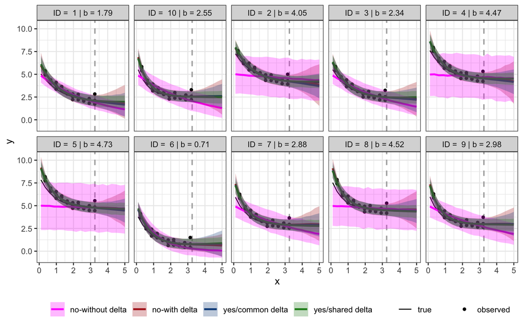

```r
# Extract means and quantiles
indy=grep("y_", rownames(smr_ysd$summary))
pred_ysd=data.frame(smr_ysd$summary[indy,c("mean", "2.5%", "97.5%")])
pred_ysd$sharing = "yes/shared delta"
smr_ycd= summary(fit_yes_common_delta)
indy=grep("y_", rownames(smr_ycd$summary))
pred_ycd=data.frame(smr_ycd$summary[indy,c("mean", "2.5%", "97.5%")])
pred_ycd$sharing = "yes/common delta"

df_pred = rbind( pred_nwd, pred_ysd, pred_nnd,pred_ycd)

df_pred$x = rep(as.vector(t(x_pred)),4)
colnames(df_pred)[2:3] = c("lower", "upper")

ID = paste("ID = ", id)
bs = paste("| b =", round(offsets,2))
ID=paste(ID, bs)
df_obs = data.frame(x=as.vector(data_population$x), y=as.vector(data_population$y), id=rep(ID,N))
df_pred$id = rep(rep(ID,each=N_pred),4)

y_true=matrix(NA,nrow = nrow(y), ncol=N_pred)
for (i in 1:Ns) {
  y_true[i,]=R(u_val[i], sort(x_pred[i,]), offsets[i])
}
df_true = data.frame(x=as.vector(t(x_pred)), y=as.vector(t(y_true)), id=rep(ID, each=N_pred))
data_fig_toy_pred = list(df_true=df_true, df_obs=df_obs, df_pred=df_pred, data_population=data_population)
# saveRDS(data_fig_toy_pred, file = "Data/data_fig_toy_pred.rds")
pl_toy_pred=ggplot()+
  geom_vline(xintercept = max(X_mat), linetype=2, colour="grey68", size=0.7)+
  geom_line(data=df_true, aes(x=x, y=y, linetype="true"))+
  geom_point(data=df_obs, aes(x=x, y=y, shape="observed"))+
  geom_line(data=df_pred, aes(x=x, y=mean, color= sharing), size=1)+
  geom_ribbon(data = df_pred, aes(x=x,ymin=lower,ymax=upper, fill=sharing),alpha=0.28)+
  facet_wrap(~id, nrow = 2)+
  theme_bw()+
  theme(legend.position = "bottom", legend.title = element_blank())+
  scale_color_manual(
    breaks=c('no-without delta','no-with delta', "yes/common delta", "yes/shared delta"),
    values=c("magenta","firebrick","dodgerblue4", "forestgreen"))+
  scale_fill_manual(
    breaks=c('no-without delta','no-with delta', "yes/common delta", "yes/shared delta"),
    values=c("magenta","firebrick","dodgerblue4", "forestgreen"))
pl_toy_pred
```

```r
# ggsave("Figs/toy_pred.pdf", plot = pl_toy_pred, width = 20, height = 12, units = "cm")
```

#### Plot individual posteriors for u (Figure 1 in the Appendix)

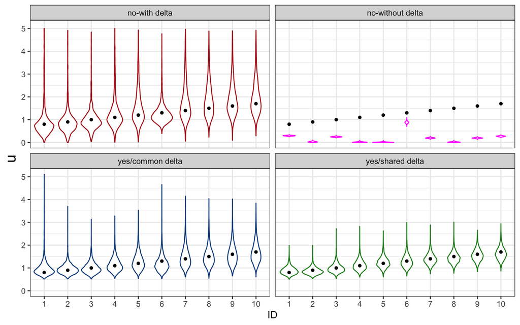

```r
### create posterior densities plot
ex_ycd=extract(fit_yes_common_delta)
ex_ysd=extract(fit_yes_shared_delta)

nnd_u = nwd_u = c()
for(i in 1:Ns){
  nwd_u = c(nwd_u,lu[[i]])
  nnd_u = c(nnd_u,lu_no[[i]])
}

n_sam = nrow(ex_ycd$u)
post_nnd = data.frame(u = nnd_u, id = rep(id,each=n_sam), sharing='no-without delta')
post_nwd = data.frame(u = nwd_u, id = rep(id,each=n_sam), sharing='no-with delta')
post_ycd = data.frame(u = as.vector(ex_ycd$u), id = rep(id,each=n_sam), sharing='yes/common delta')
post_ysd = data.frame(u = as.vector(ex_ysd$u), id = rep(id, each = n_sam), sharing='yes/shared delta')
post_u_df = rbind( post_nnd,post_nwd, post_ycd, post_ysd)
u_true_df= data.frame(u = u_val, id = as.factor(id))
data_post_toy = list(post_u_df = post_u_df, u_true_df = u_true_df)
# saveRDS(data_post_toy, file = "Data/data_post_toy.rds")
(post_toy=ggplot() +
  geom_violin(data = post_u_df, aes(x = as.factor(id), y=u, color = sharing))+
  theme_bw()+
  theme(axis.title.y = element_text(size = rel(1.5)), legend.position = "none")+
  geom_point(data = u_true_df, aes(x = id, y = u, shape = "true"))+
  facet_wrap(sharing~.)+
  xlab("ID")+
  scale_color_manual(
    breaks=c('no-without delta', 'no-with delta', "yes/common delta", "yes/shared delta"),
    values=c("magenta","firebrick","dodgerblue4", "forestgreen")))
```

```r
# ggsave("Figs/post_toy.pdf", plot = post_toy, width = 18, height = 12, units = "cm")
```